# tp4

### 1

```r
echans<-rnorm(20,1,sqrt(2))
mu0<-1
mu1<-1.5
alpha<-0.05
```

# (a) definition de α

On remarque que α est l’erreur de première espèce , il s’appelle aussi niveau de significativité. α = P[accepter H1 ;alors que H0 vraie] , est la probabilité de rejeter à tort l’hypothèse nulle ;

# (b) Donner la forme de la zone de rejet W

La région critique optimale W est définie:
$$W = {\Lambda_n > K_{\alpha}} \quad , \quad \Lambda_n = \frac{\sqrt{n}(\bar{X_n} - \mu_0)}{S_n}$$
et on a
$$\quad K_{\alpha} =F_{T_{n-1}}^{-1}(1 - \alpha)$$
où
$$F_{T_{n-1}}$$
désigne la fonction de répartition de
$$T_{n-1}$$

# (c)Programmer la regle de decision associé δ(Sn, α, μ0, μ1) ( ecrire une fonction R parametrée par les moyennes, α, et Sn).

```r
delta <- function(Sn, alpha, mu0, mu1){
  n<-length(Sn)

    means<-mean(Sn)

    sum<-0
    for (i in 1:n ) {
      sum= sum + (Sn[i]-means)*(Sn[i]-means)
    }
    Sn_2<-1.0/(n-1)*sum
    lambda_n<-sqrt(n/Sn_2)*(means-mu0)
    K<-qt(1-alpha,n-1)

   return(lambda_n>K)

}
test<-delta(echans,alpha,mu0,mu1)
if(test) {
  cat("\n On rejette donc l’hypothèse H0 :μ = ",mu1)
}else{
  cat("\nOn rejette donc l’hypothèse H1  :μ = ",mu0)
}
```

```
##
## On rejette donc l’hypothèse H1  :μ =  1
```

### 2

```r
echans_n<-matrix(rnorm(20*100, 1,sqrt(2)),nrow = 20)
```

# (a)Appliquer la règle de decision

```r
app<-function(echans_n,alpha,mu0,mu1){
n<-length(echans_n[1,])
result=vector(length=n)

for (i in 1:n) {
  test<-delta(echans_n[,i],alpha,mu0,mu1)

if(test) {
  result[i]=mu1
}else{
  result[i]=mu0
}

}

return(result)
}

print(app(echans_n,0.05,mu0,mu1))
```

```
##   [1] 1.0 1.0 1.0 1.0 1.0 1.0 1.0 1.0 1.0 1.0 1.0 1.0 1.0 1.0 1.0 1.0 1.0
##  [18] 1.0 1.0 1.0 1.0 1.0 1.0 1.0 1.0 1.0 1.0 1.0 1.0 1.0 1.0 1.0 1.0 1.0
##  [35] 1.0 1.0 1.0 1.0 1.0 1.5 1.0 1.0 1.0 1.0 1.0 1.0 1.0 1.0 1.0 1.5 1.0
##  [52] 1.0 1.0 1.0 1.0 1.0 1.0 1.0 1.0 1.0 1.0 1.0 1.0 1.0 1.0 1.0 1.0 1.0
##  [69] 1.0 1.0 1.0 1.0 1.0 1.0 1.0 1.0 1.0 1.0 1.0 1.0 1.5 1.0 1.5 1.0 1.0
##  [86] 1.0 1.0 1.0 1.0 1.0 1.0 1.0 1.0 1.0 1.0 1.0 1.0 1.0 1.0 1.0
```

On remarque on rejette plus H1 , le majorité de resultat est mu0

# (b)Faire varier α = 0.2, 0.1, 0.05, 0.01

# (c) appliquer Pourα=0.2,0.1,0.05,0.01

```r
#la probabilite on choisit Hx
P<-function(res,x){
  n=length(res)
  occ=0.0
  for (i in 1:n ){
    if (res[i]==x) {
      occ=occ+1.0
    }
  }
  return(occ/n)

}
nombre<-function(res,x){
  n=length(res)
  occ=0.0
  for (i in 1:n ){
    if (res[i]==x) {
      occ=occ+1.0
    }
  }
  return(occ)

}
NB<-vector(length=4)
cat("les alphas et les probabilite on choisit le H1")
```

```
## les alphas et les probabilite on choisit le H1
```

```r
cat("\nalpha= 0.2",1-P(app(echans_n,0.2,mu0,mu1),1))
```

```
##
## alpha= 0.2 0.17
```

```r
NB[1]<-nombre(app(echans_n,0.2,mu0,mu1),1)



cat("\nalpha= 0.1",1-P(app(echans_n,0.1,mu0,mu1),1))
```

```
##
## alpha= 0.1 0.1
```

```r
NB[2]<-nombre(app(echans_n,0.1,mu0,mu1),1)


cat("\nalpha= 0.05",1-P(app(echans_n,0.05,mu0,mu1),1))
```

```
##
## alpha= 0.05 0.04
```

```r
NB[3]<-nombre(app(echans_n,0.05,mu0,mu1),1)



cat("\nalpha= 0.01",1-P(app(echans_n,0.01,mu0,mu1),1))
```

```
##
## alpha= 0.01 0
```

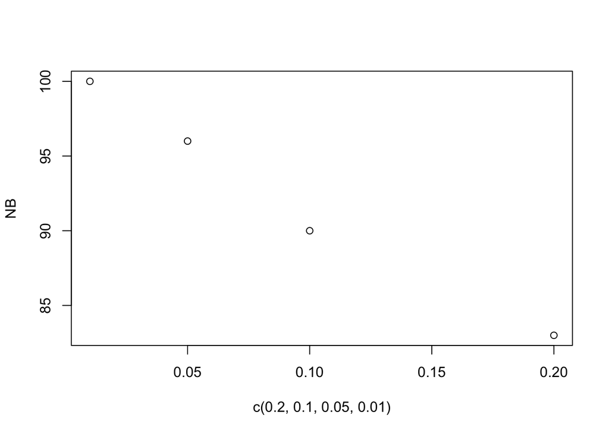

```r
NB[4]<-nombre(app(echans_n,0.01,mu0,mu1),1)


plot(x=c(0.2,0.1,0.05,0.01),NB)
```

### 3 On va simuler N = 100 ́echantillons

```r
echans_n2<-matrix(rnorm(20*100, 1.5,sqrt(2)),nrow = 20)
```

# (a)Appliquer la règle de decision,Qu’observez vous?

```r
print(app(echans_n2,0.05,mu0,mu1))
```

```
##   [1] 1.5 1.0 1.5 1.5 1.5 1.5 1.5 1.0 1.5 1.5 1.0 1.0 1.0 1.0 1.0 1.5 1.0
##  [18] 1.0 1.5 1.0 1.0 1.0 1.0 1.0 1.5 1.5 1.0 1.0 1.0 1.0 1.5 1.0 1.5 1.5
##  [35] 1.5 1.5 1.0 1.0 1.0 1.5 1.5 1.0 1.5 1.0 1.5 1.0 1.5 1.5 1.5 1.5 1.0
##  [52] 1.5 1.5 1.5 1.5 1.5 1.5 1.5 1.5 1.0 1.5 1.5 1.5 1.0 1.5 1.0 1.5 1.5
##  [69] 1.0 1.0 1.0 1.0 1.0 1.0 1.5 1.0 1.0 1.5 1.0 1.5 1.0 1.0 1.5 1.0 1.0
##  [86] 1.5 1.0 1.0 1.0 1.0 1.5 1.0 1.5 1.0 1.0 1.5 1.5 1.5 1.0 1.0
```

```r
cat("la probabilité que on choisit mu0",P(app(echans_n2,0.05,mu0,mu1),1))
```

```
## la probabilité que on choisit mu0 0.51
```

On trouve que la probabilité que on rejette H0 est autant que on rejette H1 , pour ce cas μ=1.5=μ1 , mais la fonction R suppose H0 est vrai.

# (b) Rappeler la d ́efinition et calculer th ́eoriquement la puissance du test β, en fonction de α, μ0, μ1.

```r
Puissance_de_beda<-function(Sn,alpha,mu0,mu1){
   n<-length(Sn)

    means<-mean(Sn)


    sum<-0
    for (j in 1:n ) {
      sum= sum + (Sn[j]-means)*(Sn[j]-means)
    }
    Sn_2<-1.0/(n-1)*sum

    K<-qt(1-alpha,n-1)
    result=1-pt(sqrt(n/Sn_2)*(mu0-mu1)+K,n-1)



return(result)
}

Puissance_de_beda(echans_n2[,1],0.05,mu0,mu1)
```

```
## [1] 0.4436135
```

# (c) On fixe α = 0.05, et on fait varier l’hypoth`ese alternative H1 : μ = μ . Simuler N = 100 ́echantillons S′1, . . . , S′N en faisant varier la 1nn moyenne μ = μ1 ∈ {1.2, 1.3, 1.4, 1.5, 1.6, 1.7, 1.8, 1.9, 2.0} et appliquer la regle de d ́ecision δ(S′i,α,μ ,μ ), i = 1,…,N. Tracer en fonction n01 de μ1 le pourcentage de bonne d ́ecision et comparer avec les r ́esultats de la question pr ́ec edente.

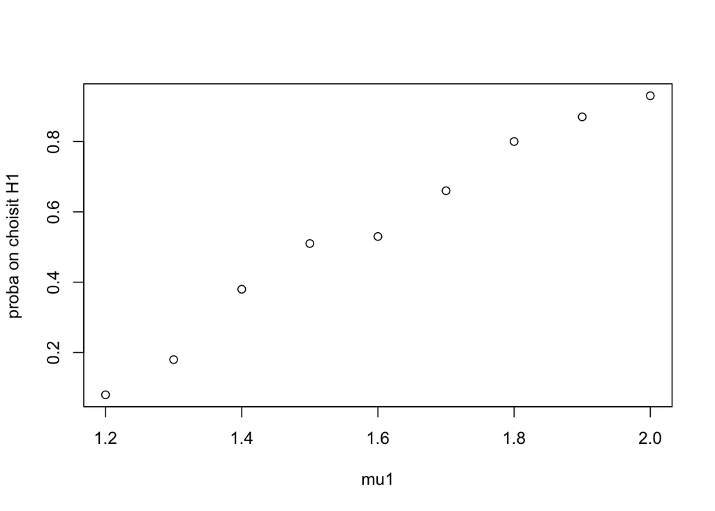

```r
res<-vector(length=9)
for (i in seq(1.2,2.0,0.1)){
 echans_n2<-matrix(rnorm(20*100, i,sqrt(2)),nrow = 20)
res[i*10-11]<-1-P(app(echans_n2,0.05,1,i),1)

}


plot(seq(1.2,2.0,0.1),res,xlab="mu1",ylab="proba on choisit H1")
```

### 4 On va utiliser la fonction R t.test qui permet de faire le test d’une hy- pothese simple H0 : μ = μ0, contre une hypoth`ese multiple (ou composite) H1 :μ>μ0 (ouμ̸=μ0).

# (a) t.test

```r
echans_n<-matrix(rnorm(20*100, 1,sqrt(2)),nrow = 20)
t.test(echans_n[,1],mu=mu0, alternative=c("greater"))
```

```
##
##  One Sample t-test
##
## data:  echans_n[, 1]
## t = 0.32912, df = 19, p-value = 0.3728
## alternative hypothesis: true mean is greater than 1
## 95 percent confidence interval:
##  0.5287284       Inf
## sample estimates:
## mean of x
##  1.110788
```

Test bilatéral

```r
t.test(echans_n[,1],mu=mu0)
```

```
##
##  One Sample t-test
##
## data:  echans_n[, 1]
## t = 0.32912, df = 19, p-value = 0.7457
## alternative hypothesis: true mean is not equal to 1
## 95 percent confidence interval:
##  0.4062354 1.8153415
## sample estimates:
## mean of x
##  1.110788
```

t est la value de la statistique Student df est le degré de liberté pour la statistique Student.

# (b)

# (c)

```r
apply2<-function(echans_n,alpha,mu0,mu1){
n<-length(echans_n[1,])
result=vector(length=n)

for (i in 1:n) {
  p <- t.test(echans_n[,i], mu=mu0, alternative=c("greater"))$p.value

if(p<alpha) {
  result[i]=mu1
}else{
  result[i]=mu0
}

}
return(result)
}

NB<-vector(length=4)
cat("les alphas et les probabilite on choisit le H1")
```

```
## les alphas et les probabilite on choisit le H1
```

```r
cat("\nalpha= 0.2",1-P(apply2(echans_n,0.2,mu0,mu1),1))
```

```
##
## alpha= 0.2 0.15
```

```r
NB[1]<-nombre(apply2(echans_n,0.2,mu0,mu1),1)



cat("\nalpha= 0.1",1-P(apply2(echans_n,0.1,mu0,mu1),1))
```

```
##
## alpha= 0.1 0.09
```

```r
NB[2]<-nombre(apply2(echans_n,0.1,mu0,mu1),1)


cat("\nalpha= 0.05",1-P(apply2(echans_n,0.05,mu0,mu1),1))
```

```
##
## alpha= 0.05 0.05
```

```r
NB[3]<-nombre(apply2(echans_n,0.05,mu0,mu1),1)



cat("\nalpha= 0.01",1-P(apply2(echans_n,0.01,mu0,mu1),1))
```

```
##
## alpha= 0.01 0.01
```

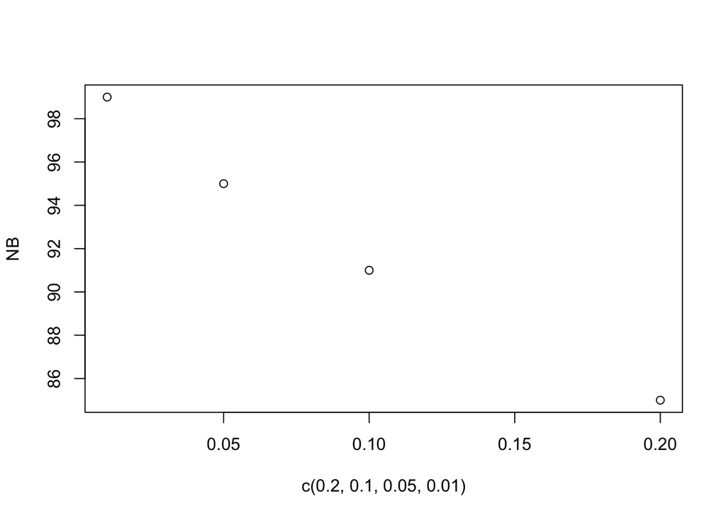

```r
NB[4]<-nombre(apply2(echans_n,0.01,mu0,mu1),1)


plot(x=c(0.2,0.1,0.05,0.01),NB)
```

# (d)Est ce normal ?

```r
print(nombre(app(echans_n,0.2,mu0,mu1),1))
```

```
## [1] 85
```

```r
print(nombre(apply2(echans_n,0.2,mu0,mu1),1))
```

```
## [1] 85
```

```r
print(nombre(app(echans_n,0.1,mu0,mu1),1))
```

```
## [1] 91
```

```r
print(nombre(apply2(echans_n,0.1,mu0,mu1),1))
```

```
## [1] 91
```

```r
print(nombre(app(echans_n,0.05,mu0,mu1),1))
```

```
## [1] 95
```

```r
print(nombre(apply2(echans_n,0.05,mu0,mu1),1))
```

```
## [1] 95
```

```r
print(nombre(apply2(echans_n,0.01,mu0,mu1),1))
```

```
## [1] 99
```

```r
print(nombre(apply2(echans_n,0.01,mu0,mu1),1))
```

```
## [1] 99
```